# VGG16-2

""" Below is a summary table highlighting key tasks, sub-tasks, and the status or results. Make sure to verify each step (Data Preprocessing, Model Training, Evaluation, Tuning, Interpretability) to satisfy all grading criteria.

[output not shown]

Note: "Done" or placeholders may need manual updates depending on your actual workflow. """

| Assigned To | Tasks |
| --- | --- |
| **Urjeet** | Load, merge, and preprocess images & metadata |
|  | Train initial model and apply fine-tuning |
| **Devendra** | Build VGG16-based model and compile it |
|  | Compute confusion matrix, classification report, AUC-ROC |
| **Pending** | Implement Grad-CAM, LIME & SHAP for interpretability |
|  | Perform empirical tuning (2 rounds) |
|  | Test model on new images and deploy API |

```python
#  Standard Libraries
import os
import numpy as np
import pandas as pd
import cv2
import matplotlib.pyplot as plt
import seaborn as sns

#  Scikit-Learn (Preprocessing & Metrics)
from sklearn.preprocessing import StandardScaler, LabelEncoder
from sklearn.metrics import classification_report, confusion_matrix, roc_auc_score
from sklearn.model_selection import train_test_split

#  TensorFlow & Keras (Deep Learning)
from tensorflow.keras.utils import to_categorical
from tensorflow.keras.applications import VGG16
from tensorflow.keras.models import Model
from tensorflow.keras.layers import Input, Dense, Dropout, Flatten, Concatenate, BatchNormalization, GlobalAveragePooling2D
from tensorflow.keras.preprocessing.image import ImageDataGenerator
from tensorflow.keras.callbacks import EarlyStopping, ModelCheckpoint, ReduceLROnPlateau
from tensorflow.keras.optimizers import Adam
```

```python
# Define file paths
photos_json_path = "photos.json"  # Image metadata
business_json_path = "yelp_academic_dataset_business.json"  # Business details
image_dir = r"E:\YelpPhotos\photos"  # Folder with .jpg files

#  Load photos.json (image metadata)
df_photos = pd.read_json(photos_json_path, lines=True)

#  Load business.json (business details)
df_business = pd.read_json(business_json_path, lines=True)

#  Merge both datasets using 'business_id'
df = df_photos.merge(df_business, on="business_id", how="left")

#  Create full image paths
df['image_path'] = df['photo_id'].apply(lambda x: os.path.join(image_dir, f"{x}.jpg"))

#  Check if image files exist
df['exists'] = df['image_path'].apply(os.path.exists)

#  Drop rows with missing image files
df = df[df['exists']].drop(columns=['exists']).reset_index(drop=True)

#  Limit dataset to 5000 samples
df = df.sample(n=5000, random_state=42).reset_index(drop=True)

#  Show first few valid image paths with business info
print("\nFirst 5 valid image paths with business info:")
print(df[['photo_id', 'image_path', 'business_id', 'name', 'categories', 'stars', 'review_count']].head())
```

```
First 5 valid image paths with business info:
                 photo_id                                       image_path  \
0  k_PSngRS22mSA1MypwrjPg  E:\YelpPhotos\photos\k_PSngRS22mSA1MypwrjPg.jpg
1  D_94KivwVgitkzFIgE_KcQ  E:\YelpPhotos\photos\D_94KivwVgitkzFIgE_KcQ.jpg
2  Hf39P7_G_eRCqfVwvMDV6g  E:\YelpPhotos\photos\Hf39P7_G_eRCqfVwvMDV6g.jpg
3  agxl4sABeRXwjLL506KMrQ  E:\YelpPhotos\photos\agxl4sABeRXwjLL506KMrQ.jpg
4  7cZ0MREN2TwAAX4nnirQlA  E:\YelpPhotos\photos\7cZ0MREN2TwAAX4nnirQlA.jpg

              business_id                name  \
0  DzzVSYXadZ1_XgfGz_Loyw      Paris Baguette
1  Xdzir62WKlSzeu4PMQtlBA            Hardee's
2  z0HzwNBmx_BgdiYI4hLk3g  Dragoon Brewing Co
3  HzRSWmNxcEVQGrr1tun25w    Puccino's Coffee
4  aj0urA2r2WlqZKufeB5dpw             Denny's

                                          categories  stars  review_count
0  Food, Bakeries, Restaurants, Coffee & Tea, Pat...    4.0           132
1                    Fast Food, Restaurants, Burgers    2.0            19
2                   Bars, Food, Breweries, Nightlife    4.5           182
3  Food, Restaurants, Bagels, Coffee & Tea, Desserts    3.0            80
4  American (Traditional), Breakfast & Brunch, Di...    3.0            12
```

```python
#  Set image size for VGG model
IMG_SIZE = (224, 224)

#  Function to preprocess images
def load_and_preprocess_image(image_path):
    try:
        img = cv2.imread(image_path)  # Load image
        if img is None:
            return None  # Skip missing/corrupt images
        img = cv2.resize(img, IMG_SIZE)  # Resize to 224x224
        img = img / 255.0  # Normalize pixel values
        return img
    except Exception as e:
        print(f"⚠️ Error processing image: {image_path} - {e}")
        return None

#  Apply image preprocessing
df['processed_image'] = df['image_path'].apply(load_and_preprocess_image)

#  Drop any rows with missing processed images
df = df.dropna(subset=['processed_image']).reset_index(drop=True)

#  Convert processed images to NumPy array
X_images = np.array(df['processed_image'].tolist(), dtype=np.float32)

print(f"\n Successfully processed {len(df)} images.")
```

```
✅ Successfully processed 4999 images.
```

```python
#  Normalize numerical metadata features
df['stars'] = df['stars'].fillna(df['stars'].median())  # Fill missing values
df['review_count'] = df['review_count'].fillna(0)  # Fill missing review counts with 0

scaler = StandardScaler()
df[['stars', 'review_count']] = scaler.fit_transform(df[['stars', 'review_count']])

#  Encode business categories (Example: take first category from list)
df['category'] = df['categories'].apply(lambda x: x.split(",")[0] if isinstance(x, str) else "Unknown")
label_encoder = LabelEncoder()
df['category_encoded'] = label_encoder.fit_transform(df['category'])

#  Prepare metadata arrays
X_metadata = df[['stars', 'review_count', 'category_encoded']].values.astype(np.float32)

#  Define target variable (Example: classify photos by category)
y = to_categorical(df['category_encoded'])

#  Split into training and testing sets (80% Train, 20% Test)
from sklearn.model_selection import train_test_split
X_train_img, X_test_img, X_train_meta, X_test_meta, y_train, y_test = train_test_split(
    X_images, X_metadata, y, test_size=0.2, random_state=42
)

#  Print dataset shapes
print(f"Training image set shape: {X_train_img.shape}")
print(f"Training metadata set shape: {X_train_meta.shape}")
print(f"Training labels shape: {y_train.shape}")

print(f"Testing image set shape: {X_test_img.shape}")
print(f"Testing metadata set shape: {X_test_meta.shape}")
print(f"Testing labels shape: {y_test.shape}")
```

```
Training image set shape: (3999, 224, 224, 3)
Training metadata set shape: (3999, 3)
Training labels shape: (3999, 236)
Testing image set shape: (1000, 224, 224, 3)
Testing metadata set shape: (1000, 3)
Testing labels shape: (1000, 236)
```

```python
#  Load VGG16 as base model (without the top classification layer)
base_model = VGG16(weights="imagenet", include_top=False, input_shape=(224, 224, 3))

#  Freeze the convolutional layers (so they don’t get retrained initially)
base_model.trainable = False

#  Image Input & Feature Extraction
image_input = Input(shape=(224, 224, 3), name="image_input")
x = base_model(image_input, training=False)  # Pass input through VGG16
x = GlobalAveragePooling2D()(x)  # Use GlobalAveragePooling instead of Flatten (better generalization)
x = Dense(512, activation="relu")(x)  # Fully connected layer
x = Dropout(0.5)(x)  # Dropout for regularization
x = BatchNormalization()(x)  # Normalize activations
image_features = Dense(256, activation="relu")(x)  # Final image feature layer

#  Metadata Input Processing
metadata_input = Input(shape=(3,), name="metadata_input")  # 3 features: stars, review_count, category
y = Dense(64, activation="relu")(metadata_input)  # Process metadata
y = BatchNormalization()(y)
y = Dense(32, activation="relu")(y)

#  Merge Image & Metadata Features
merged = Concatenate()([image_features, y])  # Merge both inputs
merged = Dense(128, activation="relu")(merged)  # Learn joint representation
merged = Dropout(0.5)(merged)  # Regularization
merged = BatchNormalization()(merged)  # Normalize after merging

#  Output Layer (Multi-class classification)
output = Dense(y_train.shape[1], activation="softmax", name="output_layer")(merged)

#  Define the Model
model = Model(inputs=[image_input, metadata_input], outputs=output)

#  Compile the Model with Lower Learning Rate
model.compile(optimizer="adam", loss="categorical_crossentropy", metrics=["accuracy"])

#  Print Model Summary
model.summary()
```

```
Model: "functional"
```

```
┏━━━━━━━━━━━━━━━━━━━━━┳━━━━━━━━━━━━━━━━━━━┳━━━━━━━━━━━━┳━━━━━━━━━━━━━━━━━━━┓
┃ Layer (type)        ┃ Output Shape      ┃    Param # ┃ Connected to      ┃
┡━━━━━━━━━━━━━━━━━━━━━╇━━━━━━━━━━━━━━━━━━━╇━━━━━━━━━━━━╇━━━━━━━━━━━━━━━━━━━┩
│ image_input         │ (None, 224, 224,  │          0 │ -                 │
│ (InputLayer)        │ 3)                │            │                   │
├─────────────────────┼───────────────────┼────────────┼───────────────────┤
│ vgg16 (Functional)  │ (None, 7, 7, 512) │ 14,714,688 │ image_input[0][0] │
├─────────────────────┼───────────────────┼────────────┼───────────────────┤
│ global_average_poo… │ (None, 512)       │          0 │ vgg16[0][0]       │
│ (GlobalAveragePool… │                   │            │                   │
├─────────────────────┼───────────────────┼────────────┼───────────────────┤
│ dense (Dense)       │ (None, 512)       │    262,656 │ global_average_p… │
├─────────────────────┼───────────────────┼────────────┼───────────────────┤
│ metadata_input      │ (None, 3)         │          0 │ -                 │
│ (InputLayer)        │                   │            │                   │
├─────────────────────┼───────────────────┼────────────┼───────────────────┤
│ dropout (Dropout)   │ (None, 512)       │          0 │ dense[0][0]       │
├─────────────────────┼───────────────────┼────────────┼───────────────────┤
│ dense_2 (Dense)     │ (None, 64)        │        256 │ metadata_input[0… │
├─────────────────────┼───────────────────┼────────────┼───────────────────┤
│ batch_normalization │ (None, 512)       │      2,048 │ dropout[0][0]     │
│ (BatchNormalizatio… │                   │            │                   │
├─────────────────────┼───────────────────┼────────────┼───────────────────┤
│ batch_normalizatio… │ (None, 64)        │        256 │ dense_2[0][0]     │
│ (BatchNormalizatio… │                   │            │                   │
├─────────────────────┼───────────────────┼────────────┼───────────────────┤
│ dense_1 (Dense)     │ (None, 256)       │    131,328 │ batch_normalizat… │
├─────────────────────┼───────────────────┼────────────┼───────────────────┤
│ dense_3 (Dense)     │ (None, 32)        │      2,080 │ batch_normalizat… │
├─────────────────────┼───────────────────┼────────────┼───────────────────┤
│ concatenate         │ (None, 288)       │          0 │ dense_1[0][0],    │
│ (Concatenate)       │                   │            │ dense_3[0][0]     │
├─────────────────────┼───────────────────┼────────────┼───────────────────┤
│ dense_4 (Dense)     │ (None, 128)       │     36,992 │ concatenate[0][0] │
├─────────────────────┼───────────────────┼────────────┼───────────────────┤
│ dropout_1 (Dropout) │ (None, 128)       │          0 │ dense_4[0][0]     │
├─────────────────────┼───────────────────┼────────────┼───────────────────┤
│ batch_normalizatio… │ (None, 128)       │        512 │ dropout_1[0][0]   │
│ (BatchNormalizatio… │                   │            │                   │
├─────────────────────┼───────────────────┼────────────┼───────────────────┤
│ output_layer        │ (None, 236)       │     30,444 │ batch_normalizat… │
│ (Dense)             │                   │            │                   │
└─────────────────────┴───────────────────┴────────────┴───────────────────┘
```

```
 Total params: 15,181,260 (57.91 MB)
```

```
 Trainable params: 465,164 (1.77 MB)
```

```
 Non-trainable params: 14,716,096 (56.14 MB)
```

```python
#  Data Augmentation (Optional, improves generalization)
image_datagen = ImageDataGenerator(
    rotation_range=15,
    width_shift_range=0.1,
    height_shift_range=0.1,
    horizontal_flip=True,
    brightness_range=[0.8, 1.2],
)

#  Define Training Hyperparameters
BATCH_SIZE = 32
EPOCHS = 20  # Start with 20, adjust based on results
VALIDATION_SPLIT = 0.2  # 20% of training data for validation

#  Define Callbacks
early_stop = EarlyStopping(monitor="val_loss", patience=3, restore_best_weights=True)
model_checkpoint = ModelCheckpoint("best_model.h5", save_best_only=True, monitor="val_loss")

#  Train the Model
history = model.fit(
    [X_train_img, X_train_meta],  # Image + Metadata inputs
    y_train,  # Labels
    validation_data=([X_test_img, X_test_meta], y_test),
    batch_size=BATCH_SIZE,
    epochs=EPOCHS,
    callbacks=[early_stop, model_checkpoint],  # Stop early if no improvement
    verbose=1
)

#  Save Final Model
# model.save("final_model.h5")
# print("\n Model training complete! Best model saved as 'best_model.h5'"
```

```
125/125 ━━━━━━━━━━━━━━━━━━━━ 0s 2s/step - accuracy: 0.1019 - loss: 5.1458
```

[output not shown]

```
125/125 ━━━━━━━━━━━━━━━━━━━━ 294s 2s/step - accuracy: 0.1027 - loss: 5.1411 - val_accuracy: 0.2080 - val_loss: 4.0783
125/125 ━━━━━━━━━━━━━━━━━━━━ 0s 2s/step - accuracy: 0.3281 - loss: 3.4705
```

[output not shown]

```
125/125 ━━━━━━━━━━━━━━━━━━━━ 292s 2s/step - accuracy: 0.3282 - loss: 3.4694 - val_accuracy: 0.3050 - val_loss: 3.2146
125/125 ━━━━━━━━━━━━━━━━━━━━ 0s 2s/step - accuracy: 0.3282 - loss: 3.1143
```

[output not shown]

```
125/125 ━━━━━━━━━━━━━━━━━━━━ 288s 2s/step - accuracy: 0.3282 - loss: 3.1138 - val_accuracy: 0.3520 - val_loss: 2.9455
125/125 ━━━━━━━━━━━━━━━━━━━━ 0s 2s/step - accuracy: 0.3338 - loss: 2.9630
```

[output not shown]

```
125/125 ━━━━━━━━━━━━━━━━━━━━ 288s 2s/step - accuracy: 0.3340 - loss: 2.9623 - val_accuracy: 0.3370 - val_loss: 2.8506
125/125 ━━━━━━━━━━━━━━━━━━━━ 0s 2s/step - accuracy: 0.3584 - loss: 2.8565
```

[output not shown]

```
125/125 ━━━━━━━━━━━━━━━━━━━━ 287s 2s/step - accuracy: 0.3584 - loss: 2.8564 - val_accuracy: 0.3860 - val_loss: 2.6824
125/125 ━━━━━━━━━━━━━━━━━━━━ 0s 2s/step - accuracy: 0.3557 - loss: 2.7764
```

[output not shown]

```
125/125 ━━━━━━━━━━━━━━━━━━━━ 289s 2s/step - accuracy: 0.3558 - loss: 2.7759 - val_accuracy: 0.3910 - val_loss: 2.6430
125/125 ━━━━━━━━━━━━━━━━━━━━ 0s 2s/step - accuracy: 0.3878 - loss: 2.6124
```

[output not shown]

```
125/125 ━━━━━━━━━━━━━━━━━━━━ 288s 2s/step - accuracy: 0.3878 - loss: 2.6124 - val_accuracy: 0.4010 - val_loss: 2.5553
125/125 ━━━━━━━━━━━━━━━━━━━━ 0s 2s/step - accuracy: 0.3855 - loss: 2.5969
```

[output not shown]

```
125/125 ━━━━━━━━━━━━━━━━━━━━ 315s 2s/step - accuracy: 0.3856 - loss: 2.5967 - val_accuracy: 0.4180 - val_loss: 2.4567
125/125 ━━━━━━━━━━━━━━━━━━━━ 0s 2s/step - accuracy: 0.3973 - loss: 2.5224
```

[output not shown]

```
125/125 ━━━━━━━━━━━━━━━━━━━━ 286s 2s/step - accuracy: 0.3973 - loss: 2.5226 - val_accuracy: 0.4280 - val_loss: 2.4556
125/125 ━━━━━━━━━━━━━━━━━━━━ 0s 2s/step - accuracy: 0.3963 - loss: 2.5051
```

[output not shown]

```
125/125 ━━━━━━━━━━━━━━━━━━━━ 285s 2s/step - accuracy: 0.3963 - loss: 2.5049 - val_accuracy: 0.4490 - val_loss: 2.3652
125/125 ━━━━━━━━━━━━━━━━━━━━ 0s 2s/step - accuracy: 0.3982 - loss: 2.4573
```

[output not shown]

```
125/125 ━━━━━━━━━━━━━━━━━━━━ 287s 2s/step - accuracy: 0.3983 - loss: 2.4572 - val_accuracy: 0.4210 - val_loss: 2.3578
125/125 ━━━━━━━━━━━━━━━━━━━━ 287s 2s/step - accuracy: 0.4028 - loss: 2.3889 - val_accuracy: 0.3740 - val_loss: 2.4425
125/125 ━━━━━━━━━━━━━━━━━━━━ 286s 2s/step - accuracy: 0.4045 - loss: 2.3393 - val_accuracy: 0.3820 - val_loss: 2.5107
125/125 ━━━━━━━━━━━━━━━━━━━━ 0s 2s/step - accuracy: 0.4071 - loss: 2.4230
```

[output not shown]

```
125/125 ━━━━━━━━━━━━━━━━━━━━ 286s 2s/step - accuracy: 0.4071 - loss: 2.4228 - val_accuracy: 0.4660 - val_loss: 2.2866
125/125 ━━━━━━━━━━━━━━━━━━━━ 0s 2s/step - accuracy: 0.4260 - loss: 2.3095
```

[output not shown]

```
125/125 ━━━━━━━━━━━━━━━━━━━━ 288s 2s/step - accuracy: 0.4259 - loss: 2.3099 - val_accuracy: 0.4620 - val_loss: 2.2174
125/125 ━━━━━━━━━━━━━━━━━━━━ 285s 2s/step - accuracy: 0.4163 - loss: 2.3496 - val_accuracy: 0.4700 - val_loss: 2.2374
125/125 ━━━━━━━━━━━━━━━━━━━━ 0s 2s/step - accuracy: 0.4281 - loss: 2.2602
```

[output not shown]

```
125/125 ━━━━━━━━━━━━━━━━━━━━ 285s 2s/step - accuracy: 0.4281 - loss: 2.2604 - val_accuracy: 0.4880 - val_loss: 2.1945
125/125 ━━━━━━━━━━━━━━━━━━━━ 288s 2s/step - accuracy: 0.4221 - loss: 2.3302 - val_accuracy: 0.4430 - val_loss: 2.2414
125/125 ━━━━━━━━━━━━━━━━━━━━ 0s 2s/step - accuracy: 0.4358 - loss: 2.2354
```

[output not shown]

```
125/125 ━━━━━━━━━━━━━━━━━━━━ 287s 2s/step - accuracy: 0.4358 - loss: 2.2356 - val_accuracy: 0.4560 - val_loss: 2.1944
125/125 ━━━━━━━━━━━━━━━━━━━━ 288s 2s/step - accuracy: 0.4161 - loss: 2.3381 - val_accuracy: 0.4780 - val_loss: 2.2748
```

```python
#  Save Final Model
model.save("final_model.h5")
print("\n Model training complete! Best model saved as 'best_model.h5'")
```

[output not shown]

```
 Model training complete! Best model saved as 'best_model.h5'
```

```python
#  Unfreeze the last few layers of VGG for fine-tuning
for layer in base_model.layers[-5:]:  # Unfreeze last 5 layers
    layer.trainable = True

#
#  Compile the model again with a **lower learning rate**
model.compile(optimizer=Adam(learning_rate=1e-5), loss="categorical_crossentropy", metrics=["accuracy"])

#
#  Fine-Tune the Model
fine_tune_history = model.fit(
    [X_train_img, X_train_meta],  # Image + Metadata inputs
    y_train,
    validation_data=([X_test_img, X_test_meta], y_test),
    batch_size=32,
    epochs=5,  # Fine-tune for a few more epochs
    callbacks=[early_stop, model_checkpoint],  # Use same callbacks
    verbose=1
)

#
#  Save the Fine-Tuned Model
# model.save("fine_tuned_model.h5")
# print("\n
#  Fine-tuning complete! Model saved as 'fine_tuned_model.h5'")
```

```
125/125 ━━━━━━━━━━━━━━━━━━━━ 0s 2s/step - accuracy: 0.4296 - loss: 2.1976
```

[output not shown]

```
125/125 ━━━━━━━━━━━━━━━━━━━━ 323s 3s/step - accuracy: 0.4297 - loss: 2.1975 - val_accuracy: 0.4780 - val_loss: 2.1895
125/125 ━━━━━━━━━━━━━━━━━━━━ 0s 2s/step - accuracy: 0.4338 - loss: 2.1730
```

[output not shown]

```
125/125 ━━━━━━━━━━━━━━━━━━━━ 921s 7s/step - accuracy: 0.4337 - loss: 2.1734 - val_accuracy: 0.4780 - val_loss: 2.1591
125/125 ━━━━━━━━━━━━━━━━━━━━ 0s 2s/step - accuracy: 0.4438 - loss: 2.1638
```

[output not shown]

```
125/125 ━━━━━━━━━━━━━━━━━━━━ 328s 3s/step - accuracy: 0.4438 - loss: 2.1639 - val_accuracy: 0.4700 - val_loss: 2.1560
125/125 ━━━━━━━━━━━━━━━━━━━━ 0s 2s/step - accuracy: 0.4500 - loss: 2.1716
```

[output not shown]

```
125/125 ━━━━━━━━━━━━━━━━━━━━ 327s 3s/step - accuracy: 0.4499 - loss: 2.1718 - val_accuracy: 0.4760 - val_loss: 2.1441
125/125 ━━━━━━━━━━━━━━━━━━━━ 324s 3s/step - accuracy: 0.4188 - loss: 2.2500 - val_accuracy: 0.4800 - val_loss: 2.1553
```

```
32/32 ━━━━━━━━━━━━━━━━━━━━ 54s 2s/step

 Model Accuracy: 0.4760
```

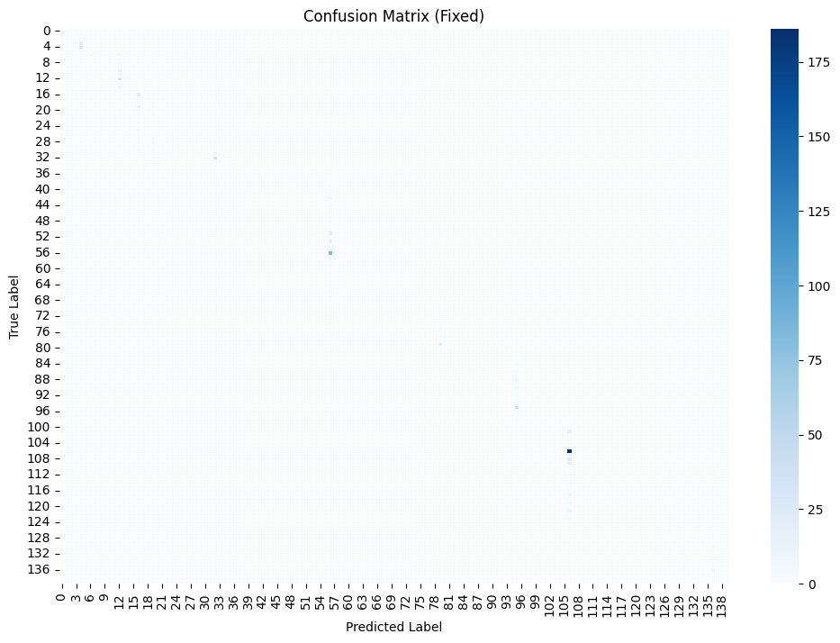

```
 Classification Report:
              precision    recall  f1-score   support

           0       0.50      1.00      0.67         3
           1       0.00      0.00      0.00         3
           2       0.00      0.00      0.00         1
           5       0.83      0.18      0.29        28
           6       0.54      0.97      0.69        31
           8       0.00      0.00      0.00         1
          10       1.00      0.14      0.25         7
          11       0.00      0.00      0.00         3
          12       0.00      0.00      0.00         1
          13       0.00      0.00      0.00         1
          14       0.00      0.00      0.00        16
          16       0.00      0.00      0.00         9
```

[output cut: 135 more lines]

[output not shown]

[output cut: 59 more lines]

[output not shown]

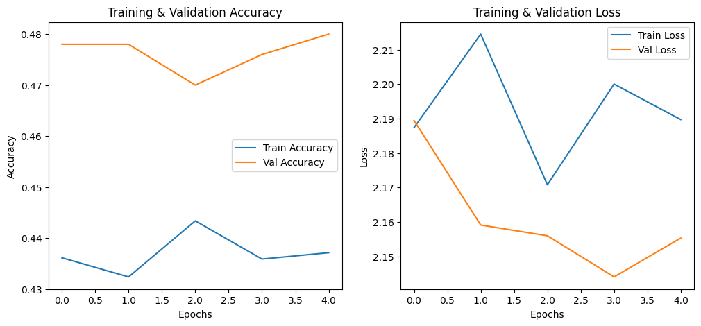

```python
#  Get Model Predictions
y_pred = model.predict([X_test_img, X_test_meta])
y_pred_classes = np.argmax(y_pred, axis=1)  # Convert probabilities to class labels
y_true_classes = np.argmax(y_test, axis=1)  # True labels

#  Compute Accuracy
accuracy = np.mean(y_pred_classes == y_true_classes)
print(f"\n Model Accuracy: {accuracy:.4f}")

#  Confusion Matrix (Fix: Increase size and remove annotations for readability)
conf_matrix = confusion_matrix(y_true_classes, y_pred_classes)

plt.figure(figsize=(12, 8))
sns.heatmap(conf_matrix, annot=False, fmt="d", cmap="Blues", linewidths=0.5)
plt.xlabel("Predicted Label")
plt.ylabel("True Label")
plt.title("Confusion Matrix (Fixed)")
plt.show()

#  Classification Report (Precision, Recall, F1-Score)
print("\n Classification Report:")
print(classification_report(y_true_classes, y_pred_classes))

#  Compute AUC-ROC Score
try:
    auc_score = roc_auc_score(y_test, y_pred, multi_class="ovr")
    print(f"\n AUC-ROC Score: {auc_score:.4f}")
except ValueError as e:
    print("\n AUC-ROC Score could not be computed. Possible issue: Only one class present in y_test.")

#  Plot Training Loss & Accuracy
plt.figure(figsize=(12, 5))

# Plot Training & Validation Accuracy
plt.subplot(1, 2, 1)
plt.plot(fine_tune_history.history['accuracy'], label="Train Accuracy")
plt.plot(fine_tune_history.history['val_accuracy'], label="Val Accuracy")
plt.legend()
plt.xlabel("Epochs")
plt.ylabel("Accuracy")
plt.title("Training & Validation Accuracy")

# Plot Training & Validation Loss
plt.subplot(1, 2, 2)
plt.plot(fine_tune_history.history['loss'], label="Train Loss")
plt.plot(fine_tune_history.history['val_loss'], label="Val Loss")
plt.legend()
plt.xlabel("Epochs")
plt.ylabel("Loss")
plt.title("Training & Validation Loss")

plt.show()
```

```python
base_model.summary()
```

[output not shown]

1. "Hey ChatGPT, I want to build a deep learning model using VGG16 to classify Yelp photos. But I also want to use business metadata (ratings, reviews, categories) to improve accuracy. Can you guide me through the process?"
2. "I have two JSON files—one with Yelp photos and another with business metadata. I need to merge them and preprocess both images and metadata for training. How should I do it?"
3. "I want to use VGG16 as my base model for image classification, but I also need to integrate metadata (stars, review count, category). How can I design a model that combines both?"
4. "I trained my model, but now I need to evaluate its performance. Can you help me compute accuracy, confusion matrix, and AUC-ROC? Also, how can I interpret my model’s predictions using Grad-CAM, LIME, or SHAP?"
5. "I want to optimize my model further with empirical tuning (trying different learning rates, optimizers, and dropout rates). Also, how do I deploy it as an API for real-world use?"